# Course Project - Practical Machine Learning

Vinicio De Sola, MFE

May 10, 2018

# Classifying the class of Unilateral Dumbbell Biceps Curl depending on wearable accelerometers’ data

## Executive Summary

In this project we’re going to use accelerometers’ data, provided by [Groupware@LES](http://groupware.les.inf.puc-rio.br/har#weight_lifting_exercises), to classify how well the Unilateral Dumbbell Curl exercise is done according to an A to E scale. We do cross-validation on the training set using a 60/40 split. We’ll do a linear SVM, a Boosted Decision Tree, and a Random Forest Classifier.

## Data

The data is already divided into a [training](https://d396qusza40orc.cloudfront.net/predmachlearn/pml-training.csv) and a [test](https://d396qusza40orc.cloudfront.net/predmachlearn/pml-testing.csv) set. The class variable goes from A to E:

-**A Exactly according to the specification**  
-**B Throwing the elbows to the front**  
-**C Lifting the dumbbell only halfway**  
-**D Lowering the dumbbell only halfway**  
-**E Throwing the hips to the front**

Only class A means that the exercise is executed correctly.

## Data cleaning and subsampling

```r
## Load the data
## All non-standard characters are turned into NA
## We set the seed as 1245 fot reproducibility
set.seed(1245)
training <- read.csv('pml-training.csv', na.strings =c('NA','#DIV/0!',""))
testing <- read.csv('pml-testing.csv',na.strings =c('NA','#DIV/0!',""))

## Data cleaning
## Remove all variables with a threshold of 5% of NA's

training <- training %>% select_if(colSums(!is.na(.)) > 0.05*nrow(.)) %>%
            .[,-c(1:7)]
testing <- testing %>% select_if(colSums(!is.na(.)) > 0.05*nrow(.)) %>%
           .[,-c(1:7)]

## Divide the training into train and validation
inTrain <- createDataPartition(training$classe, p=0.6, list = FALSE)
newTrain <- training[inTrain,]
validation <- training[-inTrain,]

## Number of variables to work with
dim(newTrain)
```

```
## [1] 11776    53
```

```r
dim(validation)
```

```
## [1] 7846   53
```

```r
dim(testing)
```

```
## [1] 20 53
```

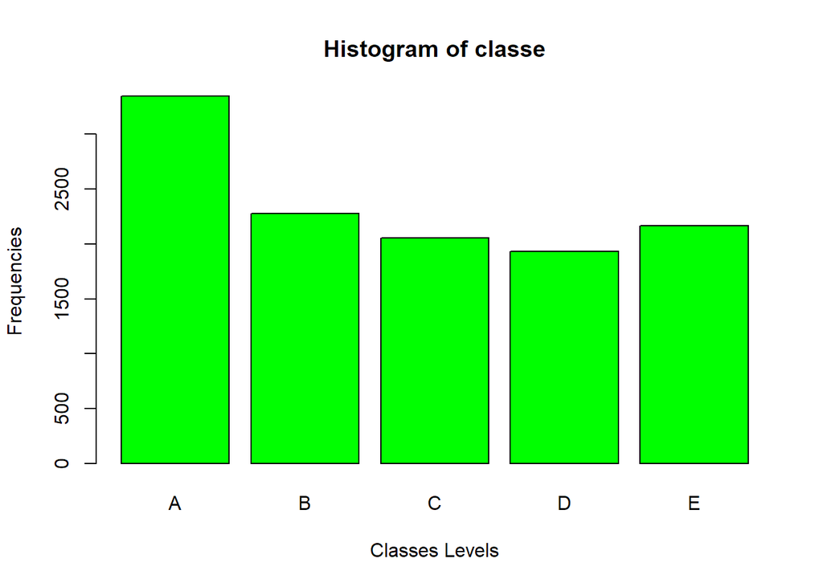

```r
## Look at the distribution of the classes
plot(newTrain$classe, col='green', main='Histogram of classe',
     xlab = 'Classes Levels', ylab='Frequencies')
```

At the end we are working with 53 variables. The training set will have 11776 observations and the validation set 7846 observations. We have the same 53 variables for the test set. The depedent variable seems balanced.

## Modeling

### SVM

Let’s start using a SVM classifier, with a linear Kernel. We’ll use a 10-fold cross-validation as a standard for all models, because it’s not too big nor too small of a k (good for the bias-variance trade-off). We need to preprocess the data (center and scale it), as needed to apply any SVM method. We also plot the cross-validation of the parameters (expressed in the grid).

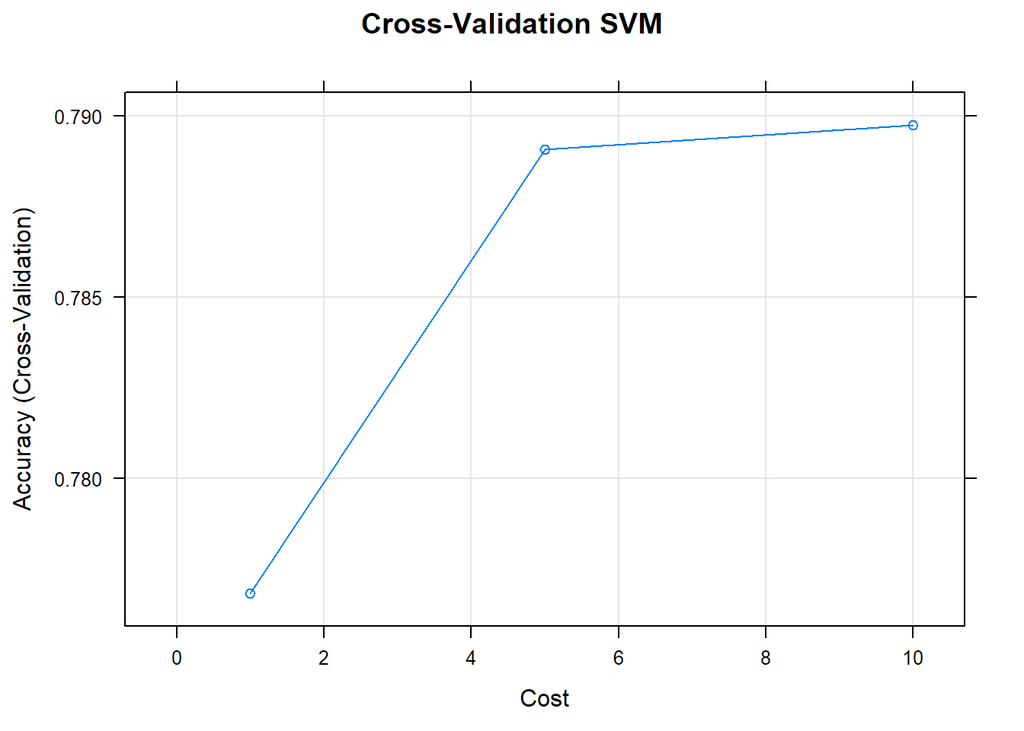

```r
set.seed(1245)
trControl <- trainControl(method='cv',number=10)
grid <- expand.grid(C = c(0,1, 5, 10))
modelSVM <- train(classe~., data=newTrain, method='svmLinear',
                  trControl = trControl, preProcess = c('center', 'scale'),
                  tuneGrid = grid,
                  tuneLenght = 10)
plot(modelSVM, main='Cross-Validation SVM')
```

```r
## Accuracy
predicSMV <- predict(modelSVM, validation, type='raw')
confusionMatrix(predicSMV, validation$classe)
```

```
## Confusion Matrix and Statistics
##
##           Reference
## Prediction    A    B    C    D    E
##          A 2051  202   90   77   81
##          B   51 1078   97   34  171
##          C   59  104 1112  133   78
##          D   61   29   30  995   86
##          E   10  105   39   47 1026
##
## Overall Statistics
##
##                Accuracy : 0.7981
##                  95% CI : (0.7891, 0.8069)
##     No Information Rate : 0.2845
##     P-Value [Acc > NIR] : < 2.2e-16
##
##                   Kappa : 0.7435
##  Mcnemar's Test P-Value : < 2.2e-16
##
## Statistics by Class:
##
##                      Class: A Class: B Class: C Class: D Class: E
## Sensitivity            0.9189   0.7101   0.8129   0.7737   0.7115
## Specificity            0.9198   0.9442   0.9423   0.9686   0.9686
## Pos Pred Value         0.8201   0.7533   0.7483   0.8285   0.8362
## Neg Pred Value         0.9661   0.9314   0.9597   0.9562   0.9372
## Prevalence             0.2845   0.1935   0.1744   0.1639   0.1838
## Detection Rate         0.2614   0.1374   0.1417   0.1268   0.1308
## Detection Prevalence   0.3188   0.1824   0.1894   0.1531   0.1564
## Balanced Accuracy      0.9194   0.8272   0.8776   0.8712   0.8401
```

We have an accuracy of 0.7981 and the cross-validation is asking for a bigger value of the grid.

### Boosted Decision Tree

We’ll use the boosted algorithm to get better results than regular decision trees. We’re going to also use 10-fold classification and preprocess the data. We also plot the cross-validation used for selection of the hyper-parameters

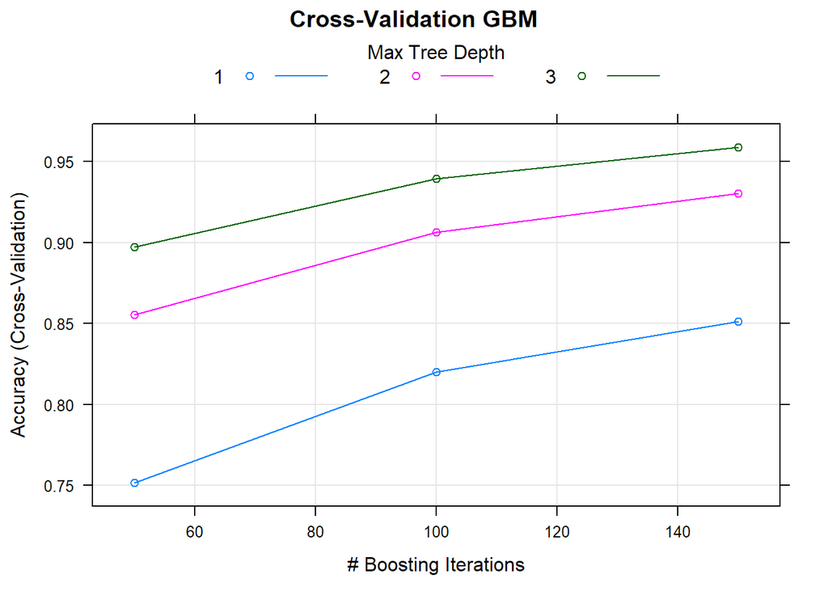

```r
set.seed(1245)
trControl <- trainControl(method='cv',number=10,
                          classProbs=T,savePredictions = T)
modelGBM <- train(classe~., data=newTrain, method='gbm',
                  preProcess = c('center', 'scale'),
                  trControl = trControl, verbose=FALSE)
predicGBM <- predict(modelGBM, validation, type='raw')
plot(modelGBM, main='Cross-Validation GBM')
```

```r
## Accuracy
confusionMatrix(predicGBM, validation$classe)
```

```
## Confusion Matrix and Statistics
##
##           Reference
## Prediction    A    B    C    D    E
##          A 2187   54    0    2    3
##          B   28 1419   45    4   17
##          C   10   42 1306   45   14
##          D    4    3   17 1226   19
##          E    3    0    0    9 1389
##
## Overall Statistics
##
##                Accuracy : 0.9593
##                  95% CI : (0.9547, 0.9636)
##     No Information Rate : 0.2845
##     P-Value [Acc > NIR] : < 2.2e-16
##
##                   Kappa : 0.9486
##  Mcnemar's Test P-Value : 2.212e-10
##
## Statistics by Class:
##
##                      Class: A Class: B Class: C Class: D Class: E
## Sensitivity            0.9798   0.9348   0.9547   0.9533   0.9632
## Specificity            0.9895   0.9851   0.9829   0.9934   0.9981
## Pos Pred Value         0.9737   0.9379   0.9217   0.9661   0.9914
## Neg Pred Value         0.9920   0.9844   0.9904   0.9909   0.9918
## Prevalence             0.2845   0.1935   0.1744   0.1639   0.1838
## Detection Rate         0.2787   0.1809   0.1665   0.1563   0.1770
## Detection Prevalence   0.2863   0.1928   0.1806   0.1617   0.1786
## Balanced Accuracy      0.9847   0.9600   0.9688   0.9734   0.9807
```

In this model, our accuracy now jumps to 0.9593, and in the cross-validation graph we can see how caret chooses the number the depth and the boosting iterations,

### Random Forest

We’re going to also use 10-fold classification and preprocess the data. We also plot the cross-validation used for selection of the hyper-parameters

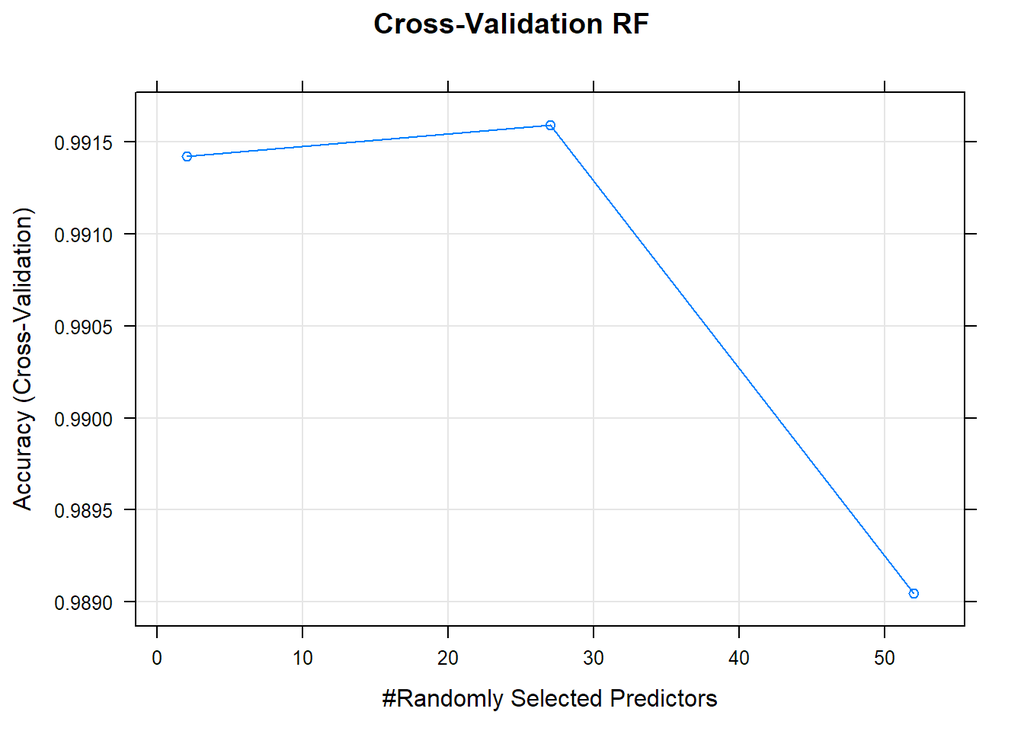

```r
set.seed(1245)
trControl <- trainControl(method='cv',number=10,
                          classProbs=T,savePredictions = T)
modelRF <- train(classe~., data=newTrain, method='rf',
                  preProcess = c('center', 'scale'),
                  trControl = trControl, verbose=FALSE)
predicRF <- predict(modelRF, validation, type='raw')
plot(modelRF, main='Cross-Validation RF')
```

```r
## Accuracy
confusionMatrix(predicRF, validation$classe)
```

```
## Confusion Matrix and Statistics
##
##           Reference
## Prediction    A    B    C    D    E
##          A 2224   14    0    0    0
##          B    1 1502    6    1    3
##          C    5    2 1358   10    0
##          D    0    0    4 1274    3
##          E    2    0    0    1 1436
##
## Overall Statistics
##
##                Accuracy : 0.9934
##                  95% CI : (0.9913, 0.995)
##     No Information Rate : 0.2845
##     P-Value [Acc > NIR] : < 2.2e-16
##
##                   Kappa : 0.9916
##  Mcnemar's Test P-Value : NA
##
## Statistics by Class:
##
##                      Class: A Class: B Class: C Class: D Class: E
## Sensitivity            0.9964   0.9895   0.9927   0.9907   0.9958
## Specificity            0.9975   0.9983   0.9974   0.9989   0.9995
## Pos Pred Value         0.9937   0.9927   0.9876   0.9945   0.9979
## Neg Pred Value         0.9986   0.9975   0.9985   0.9982   0.9991
## Prevalence             0.2845   0.1935   0.1744   0.1639   0.1838
## Detection Rate         0.2835   0.1914   0.1731   0.1624   0.1830
## Detection Prevalence   0.2852   0.1928   0.1752   0.1633   0.1834
## Balanced Accuracy      0.9970   0.9939   0.9950   0.9948   0.9977
```

## Final Prediction

Here is our final prediction using the Random Forest model

```r
prediTest <- predict(modelRF,testing)
prediTest
```

```
##  [1] B A B A A E D B A A B C B A E E A B B B
## Levels: A B C D E
```